**Machine Learning for Mechanical Engineering**  
**Final Exam: Part I**  
**06/10/2024, 6:00 PM to 7:50 PM (110 minutes)**

Prof. Seungchul Lee  
http://iailab.kaist.ac.kr/  
Industrial AI Lab at KAIST

# Problem 01

To address nonlinearly distributed datasets, it is often required to design a suitable kernel function that maps the original data into a higher-dimensional space where it becomes linearly separable. However, this step is not necessary in the context of artificial neural networks. Please discuss the reasons for this. (Hint: see the following figure.)

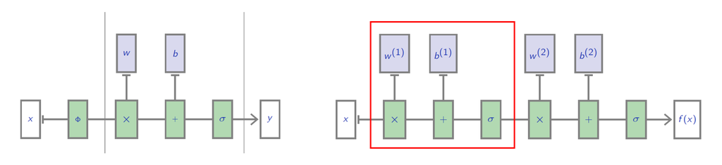

## Solution

In traditional machine learning, particularly in support vector machines (SVMs), dealing with nonlinearly distributed datasets often requires the use of kernel functions. These functions map the original data into a higher-dimensional space where it becomes linearly separable. The most common kernel functions include the polynomial kernel, radial basis function (RBF) kernel, and sigmoid kernel. This transformation allows linear classifiers to effectively classify complex datasets.

However, in artificial neural networks, particularly deep learning models, this explicit step of designing and applying a kernel function is not necessary. Here’s why:

**Hierarchical Feature Learning**

Neural networks, especially deep neural networks (DNNs), have the inherent ability to learn hierarchical representations of data. Through multiple layers, a neural network can automatically learn to extract and transform features from the raw input data into more abstract and useful representations. Each layer applies a nonlinear transformation to the data, gradually transforming it into a form where it becomes more linearly separable by the higher layers.

**Nonlinear Activation Functions** Activation functions such as ReLU (Rectified Linear Unit), sigmoid, and tanh introduce nonlinearity into the network. These nonlinear functions allow neural networks to approximate complex functions and decision boundaries. By stacking multiple layers with nonlinear activations, neural networks can model highly complex relationships in the data without the need for predefined kernels.

**End-to-End Learning** Neural networks are trained end-to-end using backpropagation. During training, the network adjusts its weights and biases in all layers simultaneously to minimize a loss function. This allows the network to learn the optimal way to transform the input data into a space where the output classes are linearly separable, as part of the training process. This is fundamentally different from SVMs, where the kernel trick is a preprocessing step that maps the data before the linear classifier is applied.

**Example with MNIST** Consider the task of classifying MNIST handwritten digits. A deep neural network might start with convolutional layers to detect edges and textures, followed by pooling layers to reduce dimensionality and focus on important features, and finally fully connected layers to integrate these features and perform classification. Throughout this process, the network learns to transform the original pixel data into a form where the digits are more easily separable, without explicitly mapping them through a predefined kernel function.

**Visualization** In neural networks, the transformation of data through layers can be visualized in a lower-dimensional space using techniques like t-SNE or PCA. These visualizations often show that the network gradually learns to cluster similar data points together, making the classes more separable in the feature space learned by the network.

**Summary** The key reasons neural networks do not require explicit kernel functions to handle nonlinearly distributed data are:

1. **Hierarchical feature learning**: Layers progressively extract higher-level features.
2. **Nonlinear activations**: Introduce necessary nonlinearity to capture complex patterns.
3. **End-to-end learning**: The entire network learns transformations to make the data linearly separable during training.

These aspects enable neural networks to inherently handle complex, nonlinearly distributed data effectively, obviating the need for manual kernel design as in traditional SVM approaches.

## Problem 02

1. Explain the difference between cross-correlation and convolution in 1D
2. (T/F) CNN cannot reduce output size without pooling layer.
3. (T/F) max pooling allows a neuron in a network to have information about features in a larger part of the image, compared to a neuron at the same depth in a network without max pooling.
4. Can you implement average pooling as a special case of a convolution layer? If so, do it.
5. Can you implement max pooling as a special case of a convolution layer? If so, do it.
6. Do we need a separate minimum pooling layer? Can you replace it with another operation?
7. In the class, we learned about the concept "walk in the latent space." Discuss why we should walk in the latent space instead of walking in the orignal space.

## Solution

**Explain the difference between cross-correlation and convolution in 1D**

Cross-correlation and convolution are two closely related operations commonly used in signal processing and neural networks. The primary difference lies in the way they process the input signal with the kernel (or filter).

  Here, $( * )$ denotes the cross-correlation operation.
- **Convolution**: Convolution is similar to cross-correlation, but it involves flipping the kernel before sliding it over the input signal. The convolution of an input signal $x$ with a kernel $k$ is defined as:

  $$(x \ast k)(t) = \sum_{i} x(t + i) k(-i)$$

  Here, $\ast$ denotes the convolution operation, and $k(-i)$ represents the flipped kernel.

**(T/F) CNN cannot reduce output size without a pooling layer.**

**False**. Convolutional Neural Networks (CNNs) can reduce the output size without using a pooling layer. This can be achieved by using convolutional layers with a stride greater than one, which reduces the spatial dimensions of the output feature maps.

**(T/F) Max pooling allows a neuron in a network to have information about features in a larger part of the image, compared to a neuron at the same depth in a network without max pooling.**

**True**. Max pooling allows neurons to capture information from larger receptive fields by downsampling the feature maps, thus enabling each neuron to aggregate features from a broader area of the input image compared to neurons in networks without pooling.

**Can you implement average pooling as a special case of a convolution layer? If so, do it.**

Yes, average pooling can be implemented as a special case of a convolution layer by using a convolutional filter with uniform weights.

Here is a simple implementation using a 1D convolutional layer in TensorFlow/Keras:

[output not shown]

**Can you implement max pooling as a special case of a convolution layer? If so, do it.**

Implementing max pooling as a special case of a convolution layer is more complex and less efficient compared to using a dedicated max pooling layer. Convolution layers are not naturally suited for max operations due to their linear nature, which makes such implementation non-trivial and typically impractical.

**Do we need a separate minimum pooling layer? Can you replace it with another operation?**

A separate minimum pooling layer is not typically necessary because minimum pooling is rarely used. If needed, minimum pooling can be approximated using the negative of max pooling:

```
# Assuming x is your input tensor
min_pooled = -tf.nn.max_pool(-x, ksize=[1, 2, 2, 1], strides=[1, 2, 2, 1], padding='VALID')
```

This approach uses the fact that max pooling on the negative of the data is equivalent to minimum pooling on the original data.

**In the class, we learned about the concept "walk in the latent space." Discuss why we should walk in the latent space instead of walking in the original space.**

Walking in the latent space is advantageous because the latent space represents a more abstract and compact representation of the data, capturing the most salient features while discarding noise and irrelevant details. Here are several reasons for preferring to walk in the latent space:

1. **Dimensionality Reduction**: The latent space is typically lower-dimensional, making exploration more efficient and computationally feasible.
2. **Meaningful Interpolation**: Interpolating between points in the latent space often results in smooth and meaningful transformations in the original space, as the latent variables capture the underlying structure of the data.
3. **Feature Abstraction**: The latent space abstracts away from raw data, focusing on high-level features that are more relevant for tasks such as generation, interpolation, and classification.
4. **Noise Reduction**: By walking in the latent space, we avoid the high-dimensional noise present in the original data, leading to more robust and meaningful outcomes.

In summary, walking in the latent space allows us to leverage the compact and informative representations learned by the model, facilitating more effective and efficient exploration and manipulation of the data.

# Problem 03

To train neural networks, backpropagation is used. Briefly explain what the backpropagation is. When you discuss it, use the keywords such as recursive, memorized, dynamic programming, chain rule, etc.

## Solution

To train neural networks, the backpropagation algorithm is employed. Backpropagation is a recursive method that iteratively adjusts the weights of the network to minimize the error between the predicted and actual outputs. The algorithm relies on several key concepts:

1. **Chain Rule**: Backpropagation utilizes the chain rule from calculus to compute the gradient of the loss function with respect to each weight in the network. This involves calculating the partial derivatives of the error with respect to the weights layer by layer, starting from the output layer and moving backwards through the network.
2. **Dynamic Programming**: The process can be viewed as a dynamic programming approach, where intermediate results (such as gradients) are stored and reused to avoid redundant calculations. This memory-efficient strategy allows for the efficient computation of gradients.
3. **Recursive Nature**: The recursive aspect of backpropagation comes from the iterative process of updating weights. For each layer, the error is propagated backward through the network, adjusting the weights recursively to reduce the error.
4. **Memorization**: During the backward pass, intermediate gradients are memorized to update the weights efficiently. This reduces the computational burden and enhances the learning process by avoiding repeated calculations of the same gradient.

In essence, backpropagation is a combination of the chain rule for gradient computation and dynamic programming for efficient memory usage, applied recursively to adjust the weights of a neural network. This method ensures that the network learns from the errors by iteratively fine-tuning its parameters, ultimately improving its performance on the given task.

# Problem 04

Build the ANN model which receives three binary-valued (i.e., $0$ or $1$) inputs $x_1,x_2,x_3$, and outputs $1$ if exactly two of the inputs are $1$, and outputs $0$ otherwise. All of the units use a hard threshold activation function:

$$z = \begin{cases} 1 \quad \text{if } z \geq 0\\ 0 \quad \text{if } z < 0 \end{cases} $$

Suggest one of possible weights and biases which correctly implement this function.

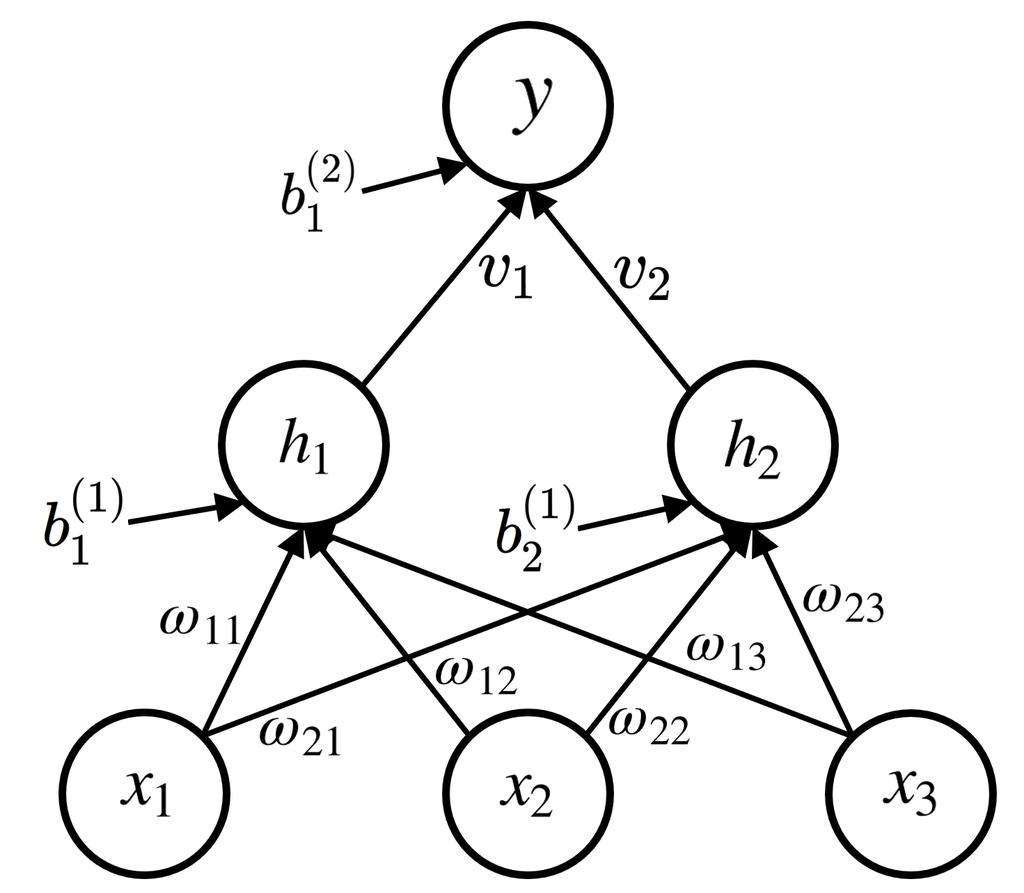

Denote by

- $\mathbf{W}_{2 \times 3}$ and $\mathbf{V}_{1 \times 2}$ weight matrices connecting input and hidden layer, and hidden layer and output respectively.
- $\mathbf{b}^{(1)}_{2 \times 1}$ and $\mathbf{b}^{(2)}_{1 \times 1}$ biases matrices at hidden layer and output, respectively.
- $x_{3 \times 1}$ and $h_{2 \times 1}$ node values at input and hidden layer, repectively.

## Solution

```python
import numpy as np

def net(x, w, v, b):
    h1 = x[0]*w[0,0] + x[1]*w[0,1] + x[2]*w[0,2] + b[0]
    h2 = x[0]*w[1,0] + x[1]*w[1,1] + x[2]*w[1,2] + b[1]

    h1 = 1 if h1 >= 0 else 0
    h2 = 1 if h2 >= 0 else 0

    y = h1*v[0] + h2*v[1] + b[2]

    y = 1 if y >= 0 else 0
    return y

def scoring(X, w, v, b, net, prt=True):
    if prt: print('input correct predict')
    score = 0
    for i in range(8):
        if i < 5:
            ans = 0
        else:
            ans = 1
        predict = net(X[i], w, v, b)
        if ans == predict:
            score += 1
        if prt: print(X[i], ans, predict)
    print('score : {}/8'.format(score))

X = np.array([[0, 0, 0],
              [1, 0, 0],
              [0, 1, 0],
              [0, 0, 1],
              [1, 1, 1],
              [1, 1, 0],
              [1, 0, 1],
              [0, 1, 1]])

w = np.array([1, 1, 1, -1, -1, -1]).reshape(2, 3)
v = np.array([1, 1])
b = np.array([-2, 2, -2])

bool_print = True
scoring(X, w, v, b, net, bool_print)
```

```
input correct predict
[0 0 0] 0 0
[1 0 0] 0 0
[0 1 0] 0 0
[0 0 1] 0 0
[1 1 1] 0 0
[1 1 0] 1 1
[1 0 1] 1 1
[0 1 1] 1 1
score : 8/8
```

# Problem 05

The below image depicts a training process of a single layer perceptron.

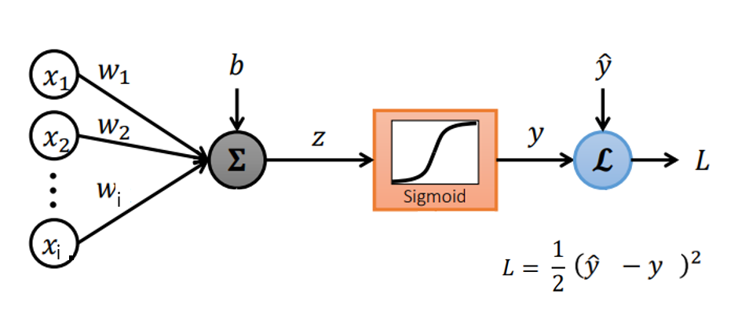

1. Express $\frac{\partial{L}}{\partial{w_i}}$ in terms of $x_i$, $\hat{y}$, and ${y}$.

Hint: sigmoid function is as follows $\sigma(x) = \dfrac{1}{1 + e^{-x}}$

2. Explain why gradient vanishing occurs as the model with sigmoid activation function goes deeper.
- Use the chain rule to explain gradient vanishing centering on $\omega_1$, $\omega_2$ and $\omega_3$.
- Hint: gradient vanishing means that gradients become extremely small as they propagate backward through the network

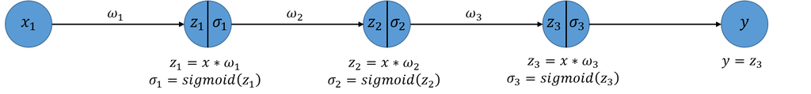

## Solution

$$ \begin{align*} \frac{\partial{L}}{\partial{w_i}} = \frac{\partial{z}}{\partial{w_i}} \times \frac{\partial{y}}{\partial{z}} \times\frac{\partial{L}}{\partial{y}} \\\\ \end{align*} $$$$ \begin{align*} \frac{\partial{L}}{\partial{w_i}} = - x_i \times y \times (1-y) \times (\hat{y}-y) \\\\ \end{align*} $$

**$w_3$ update**

$$ \begin{align*} \\\\ \frac{\partial E}{\partial \omega_3} = \frac{\partial E}{\partial \sigma_3} \times \frac{\partial \sigma_3}{\partial z_3} \times \frac{\partial z_3}{\partial \omega_3} \\\\ \end{align*} $$$$ \begin{align*} \frac{\partial \sigma_3}{\partial z_3} = \sigma_3 \times (1 - \sigma_3) \\\\ \end{align*} $$

**$w_2$ update**

$$ \begin{align*} \\\\ \frac{\partial E}{\partial \omega_2} = \frac{\partial E}{\partial \sigma_3} \times \frac{\partial \sigma_3}{\partial z_3} \times \frac{\partial z_3}{\partial \sigma_2} \times \frac{\partial \sigma_2}{\partial z_2} \times \frac{\partial z_2}{\partial \omega_2} \\\\ \end{align*} $$$$ \begin{align*} \frac{\partial \sigma_2}{\partial z_2} = \sigma_2 \times (1 - \sigma_2) \space, \space \space \space \space \space \frac{\partial \sigma_3}{\partial z_3} = \sigma_3 \times (1 - \sigma_3) \\\\ \end{align*} $$

**$w_1$ update**

$$ \begin{align*} \\\\ \frac{\partial E}{\partial \omega_1} = \frac{\partial E}{\partial \sigma_3} \times \frac{\partial \sigma_3}{\partial z_3} \times \frac{\partial z_3}{\partial \sigma_2} \times \frac{\partial \sigma_2}{\partial z_2} \times \frac{\partial z_2}{\partial \sigma_1} \times \frac{\partial \sigma_1}{\partial z_1} \times \frac{\partial z_1}{\partial \omega_1} \\\\ \end{align*} $$$$ \begin{align*} \frac{\partial \sigma_1}{\partial z_1} = \sigma_1 \times (1 - \sigma_1) \space, \space \space \space \space \space \frac{\partial \sigma_2}{\partial z_2} = \sigma_2 \times (1 - \sigma_2) \space, \space \space \space \space \space \frac{\partial \sigma_3}{\partial z_3} = \sigma_3 \times (1 - \sigma_3) \\\\ \end{align*} $$

The deeper the layer, the more derivative terms of the sigmoid function. Since the sigmoid function always has a value less than 1, the gradient gradually converges to 0 as the layer gets deeper.

# Problem 06

1. (Choose correct answers) John just trained a decision tree for a digit recognition. He notices an extremely low training error, but an abnormally large test error. He also notices that an SVM with a nonlinear kernel performs much better than his tree. What could be the cause of his problem? (2 choices)

a) Decision tree is too deep

b) Decision tree is overfitting

c) Learning rate is too high

d) There is too much training data

2. (Choose correct answers) Anne has now switched to multilayer neural networks and notices that the training error is going down and converges to a local minimum. Then when she tests on the new data, the test error is abnormally high. What is probably going wrong and what do you recommend her to do? (3 choices)

a)The training data size is not large enough. Collect a larger training data and retrain it.

b) Play with learning rate and add regularization term to the objective function.

c) Use a different initialization and train the network several times. Use the average of predictions from all nets to predict test data.

d) Use the same training data but add two more hidden layers.

3. (Choose all the correct answers) Jessica is tyring to solve the XOR problem using a multilayer perceptron (MLP). However, as she trains the MLP model, the results vary at every iteration. The results are correct in some iterations, and the results are wrong at the other iterations. What is probably going wrong and what do you recommend her to do?

a) The training data points are not large enough. Collect a larger training data points and re-train it.

b) The number of perceptron layers is too large. Remove the perceptron layers and re-train it.

c) The number of perceptron layers is too small. Add more the perceptron layers and re-train it.

d) Learning rate is too high. Reduce learning rate and re-train it.

## Solution

1. a) and b)
2. a), b), and c)
3. c) and d)

# Problem 07

For each of the following questions, choose correct options. Each question has **AT LEAST** one correct option. No explanation is required.

a) Which of the following is true about dropout?

1. Dropout leads to sparsity in the trained weights
2. At test time, dropout is applied with probability maintained
3. The larger the keep probability of a layer, the stronger the regularization of the weights in that layer
4. None of the above

b) During backpropagation, as the gradient flows backward through a sigmoid function, the gradient will always:

1. Increase in magnitude
2. Decrease in magnitude
3. Maintain sign
4. Reverse sign

c) You are training a large feedforward neural network (100 layers) on a binary classification task, using a sigmoid activation in the final layer, and a mixture of tanh and ReLU activations for all other layers. You notice your weights to your a subset of your layers stop updating after the first epoch of training, even though your network has not yet converged. Which of the following fixes could help? (You also note that your loss is still within a reasonable order of magnitude).

1. Increase the size of your training set
2. Switch the ReLU activations with leaky ReLUs everywhere
3. Add Batch Normalization before every activation
4. Increase the learning rate

## Solution

a) 4

b) 2, 3

c) 2, 3

# Problem 08

1. Explain why the perceptron cannot solve the XOR problem.
2. ANN (Artificial Neural Networks) is also called as MLP (Multilayer Perceptron). Explain why the MLP is able to solve the XOR problem.
3. Explain why the autoencoder is one of unsupervised learning algorithms.
4. Explain how the autoencoder can work as a feature extraction.

## Solution

**Why the Perceptron Cannot Solve the XOR Problem**

A single-layer perceptron can only solve problems that are linearly separable. This means that it can only classify data points that can be separated by a straight line (or hyperplane in higher dimensions). The XOR problem is a classic example of a non-linearly separable problem.

In the XOR problem, the data points (0,0) and (1,1) belong to one class, and the data points (0,1) and (1,0) belong to another class. There is no straight line that can separate these two classes in the 2D input space, as the XOR function outputs 1 only when the inputs are different. Therefore, a single-layer perceptron cannot solve the XOR problem because it cannot draw a linear boundary between the classes.

**Why the MLP (Multilayer Perceptron) Can Solve the XOR Problem**

A Multilayer Perceptron (MLP) includes one or more hidden layers with non-linear activation functions. These hidden layers enable the network to capture and represent complex patterns and relationships in the data. Specifically, an MLP can create non-linear decision boundaries by combining multiple linear boundaries from its neurons.

For the XOR problem, an MLP with one hidden layer and non-linear activation functions (like sigmoid, tanh, or ReLU) can learn to transform the input space in such a way that the classes become linearly separable in the transformed space. Essentially, the hidden layer allows the MLP to map the input to a higher-dimensional space where a linear separation is possible, thus enabling it to solve the XOR problem.

**Why the Autoencoder is One of Unsupervised Learning Algorithms**

An autoencoder is an unsupervised learning algorithm because it does not require labeled data for training. Instead, it aims to learn an efficient representation of the input data by reconstructing it as accurately as possible.

The autoencoder consists of two parts:

1. **Encoder**: This part compresses the input data into a lower-dimensional latent space representation.
2. **Decoder**: This part reconstructs the original data from the compressed representation.

The training objective is to minimize the reconstruction error, which is the difference between the input data and its reconstruction. Since this process does not involve predicting labels or categories, it is considered unsupervised learning.

**How the Autoencoder Can Work as a Feature Extraction**

An autoencoder can be used for feature extraction by utilizing the learned representation in the latent space (the output of the encoder part). The encoder compresses the input data into a lower-dimensional representation that captures the most important features or patterns in the data. These features can be more informative and compact than the original raw input data.

Here's how the autoencoder works as a feature extractor:

1. **Training**: Train the autoencoder on the dataset to minimize the reconstruction error.
2. **Feature Extraction**: Once trained, use the encoder part to transform the input data into the latent space representation. These representations are the extracted features.

The extracted features can then be used as input to other machine learning models for tasks such as classification, clustering, or regression. By capturing the essential characteristics of the data in a reduced form, the autoencoder helps in improving the efficiency and performance of subsequent learning tasks.

# Problem 09

Two historians approach you for your deep learning expertise. They want to classify images of historical objects into 3 classes depending on the time they were created:

- Antiquity ($y = 0$)
- Middle Ages ($y = 1$)
- Modern Era ($y = 2$)

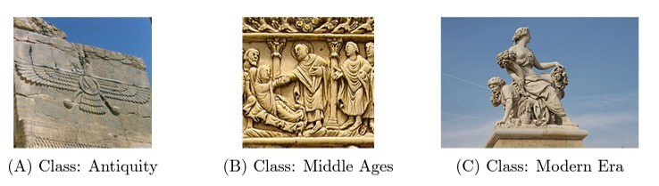

1. Over the last few years, the historians have collected nearly 5,000 hand-labelled RGB images. Before training your model, you want to decide the image resolution to be used. Why is the choice of image resolution important?
2. You have now figured out a good image resolution to use. How would you partition your dataset? Formulate your answer in percentages.
3. After visually inspecting the dataset, you realize that the training set only contains pictures taken during the day, whereas the validation set only has pictures taken at night. Explain what is the issue and how you would correct it.
4. As you train your model, you realize that you do not have enough data. Cite 3 data augmentation techniques that can be used to overcome the shortage of data.
5. You come up with a CNN classifier. For each layer, calculate the number of weights, number of biases and the size of the associated feature maps. The notation follows the convention:
- CONV-K-N denotes a convolutional layer with $N$ filters, each them of size $K \times K$. Padding and stride parameters are always $0$ and $1$, respectively.
- POOL-K indicates a $K \times K$ pooling layer with stride $K$ and padding $0$.
- FC-N stands for a fully-connected layer with $N$ neurons.

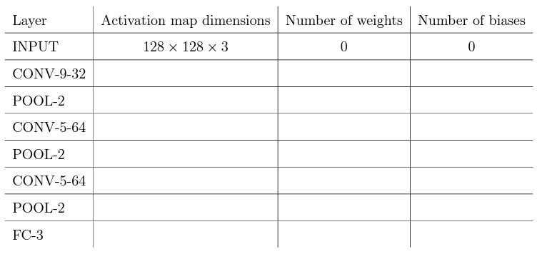

6. Why is it important to place non-linearities between the layers of neural networks?
7. Following the last FC-3 layer of your network, what activation must be applied? Given a vector $a = [0.3,0.3,0.3]$, what is the result of using your activation on this vector?

## Solution

1. Trade-off between accuracy and model complexity.
2. Several ratios possible. One way of doing it: split the initial dataset into 64% training/16% dev/20% testing set. Training on the training set and tuning the hyperparameters after looking at the performance on the dev set.
- It can cause a domain mismatch.
- The difference in the distribution of the images between training and dev might lead to faulty hyperparameter tuning on the dev set, resulting in poor performance on unseen data.
- Solution: randomly mix pictures taken at day and at night in the two sets and then resplit the data.
4. A lot of answers can be accepted, including Rotation, Cropping, Flipping, Luminosity/Contrast Changes
- $120 \times 120 \times 32$ and $32 \times (9 \times 9 \times 3+1)$
- $60 \times 60 \times 32$ and $0$
- $56 \times 56 \times 64$ and $64 \times (5 \times 5 \times 32+1)$
- $28 \times 28 \times 64$ and $0$
- $24 \times 24 \times 64$ and $64 \times (5 \times5 \times 64+1)$
- $12 \times 12 \times 64$ and $0$
- $3$ and $3 \times (12 \times 12 \times 64+1)$
6. Non-linearity introduces more degrees of freedom to the model. It lets it capture more complex representations which can be used towards the task at hand. A deep neural network without non-linearities is essentially a linear regression.
7. Softmax is the one that is used as it can output class probabilities. Output is [0.33, 0.33, 0.33]. (You don’t need a calculator!)

## Problem 10

Learning long-term dependencies in recurrent networks suﬀers from a particular numerical challenge - gradients propagated over many time-steps tend to either 'vanish' (i.e., converge to 0, frequently) or 'explode' (i.e., diverge to inﬁnity; rarely, but with more damage to the optimization). To study this problem in a simple setting, consider the following recurrence relation without any nonlinear activation function or input $x$:

$$h_t = W^\top h_{t-1}$$

where $W$ is a weight sharing matrix for recurrent relation at any time $t$. Let $\lambda_1, \cdots, \lambda_n$ be the eigenvalues of the weight matrix $W \in \mathbb{C}^{n \times n}$. Its spectral radius $\rho (W)$ is deﬁned as:

$$\rho(W) = \max \{\lvert \lambda_1 \rvert, \cdots, \lvert \lambda_n \rvert \}$$

Assuming the initial hidden state is $h_0$, write the relation between $h_T$ and $h_0$ and explain the role of the eigenvalues of $W$ in determining the 'vanishing' or 'exploding' property as $T \gg 0$

## Solution

We can rewrite $h_T = W^\top h_{T-1} = W^\top (W^\top h_{T-2}) = \dots = (W^\top)^T h_{0}$ by given formula.

Since T is larger enougn, if all eigenvalue of $W$ are less than 1, it will vanising. In other words, if spectral radius is less than 1, it will vanishing.

And if at least one eigenvalue of $W$ is greater than 1, it will exploding. In other words, if spectral radius is greater than 1, it will exploding.

## Problem 11

Architecture of a bidirectional recurrent neural network is shown in the below figure. When do you think this special bidirectional architecture is beneficial?

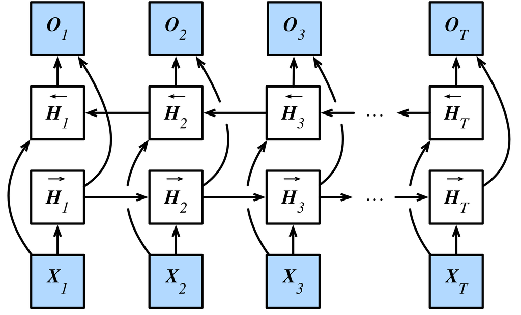

## Solution

A bidirectional recurrent neural network (BiRNN) is beneficial in various contexts where the understanding of sequential data can be enhanced by considering the context from both past and future elements. Here are some specific scenarios where this architecture is particularly useful:

1. **Natural Language Processing (NLP)**:
   - **Machine Translation**: Understanding the context of a word based on both previous and subsequent words can improve the quality of translation.
   - **Named Entity Recognition (NER)**: Identifying entities in a sentence benefits from considering the context surrounding the entity from both directions.
   - **Part-of-Speech Tagging (POS)**: Determining the correct POS tags for words requires understanding the surrounding words, which is facilitated by a bidirectional approach.
   - **Sentiment Analysis**: Analyzing the sentiment of a sentence can be more accurate when the context of the entire sentence is considered, not just the words that came before.
2. **Speech Recognition**:
   - Understanding spoken language benefits from both the preceding and following words to accurately transcribe the speech into text.
3. **Time Series Prediction**:
   - In financial forecasting, weather prediction, or any time series analysis, understanding the patterns from both past and future data points can enhance the accuracy of the predictions.
4. **Bioinformatics**:
   - Sequence alignment and DNA sequence analysis can benefit from considering the context provided by both directions of the sequence.
5. **Video Analysis**:
   - In tasks like action recognition or video captioning, understanding the sequence of frames in both forward and backward directions can provide a more comprehensive understanding of the activity.
6. **Handwriting Recognition**:
   - Recognizing handwritten text can be more accurate when the context of each character or word is considered from both directions, enhancing the ability to understand ambiguous strokes.

In essence, any task that involves sequential data and can benefit from a more comprehensive context provided by looking at both past and future elements is well-suited for a bidirectional recurrent neural network. The ability of BiRNNs to leverage information from both directions allows them to capture dependencies and patterns that unidirectional RNNs might miss.

# Problem 12

Can you explain what Physics-Informed Neural Networks (PINNs) are, including their core concepts, advantages, applications, and provide an example?

## Solution

**Physics-Informed Neural Networks (PINNs): Core Concepts**

Physics-Informed Neural Networks (PINNs) are a class of machine learning models that integrate the laws of physics into the training process of neural networks. The core idea is to embed physical laws, typically represented by partial differential equations (PDEs), directly into the neural network's loss function, enabling the model to learn solutions that are consistent with these laws.

**Core Concepts**

1. **Physics-Based Loss Function**:
   - Traditional neural networks are trained by minimizing a loss function that measures the discrepancy between predictions and actual data. In PINNs, the loss function also includes terms that enforce the satisfaction of physical laws (e.g., PDEs).
2. **Differential Operators**:
   - PINNs make use of automatic differentiation to compute derivatives of the neural network's output with respect to its inputs, which are necessary for embedding differential equations into the loss function.
3. **Boundary and Initial Conditions**:
   - To solve PDEs, boundary and initial conditions are crucial. These are included in the loss function to ensure that the neural network's solutions adhere to these conditions.

**Advantages**

1. **Data Efficiency**:
   - By incorporating known physical laws, PINNs can achieve high accuracy with less data compared to purely data-driven models.
2. **Generalization**:
   - PINNs can generalize better to new conditions that were not explicitly covered in the training data, thanks to the guidance provided by physical laws.
3. **Flexibility**:
   - PINNs can handle complex geometries and varying boundary conditions more flexibly than traditional numerical methods.
4. **Seamless Integration**:
   - They can easily integrate heterogeneous data sources, such as experimental data and simulated data, within the same framework.

**Applications**

1. **Fluid Dynamics**:
   - Solving the Navier-Stokes equations to model fluid flow in various contexts, such as weather prediction and aerodynamics.
2. **Heat Transfer**:
   - Solving heat equations to model temperature distribution in different materials and environments.
3. **Electromagnetics**:
   - Modeling electromagnetic fields using Maxwell's equations for applications in telecommunications and sensor technologies.
4. **Structural Mechanics**:
   - Analyzing stress and strain in structures by solving elasticity equations, useful in civil and mechanical engineering.
5. **Quantum Mechanics**:
   - Solving the Schrödinger equation to model quantum systems, which can be applied in material science and chemistry.

**Conclusion**

Physics-Informed Neural Networks provide a powerful framework for solving complex physical problems by blending data-driven approaches with established physical laws. Their ability to incorporate differential equations into the learning process allows for more accurate and efficient modeling of systems governed by physics, making them highly valuable in scientific and engineering applications.

# Problem 13

Artificial Intelligence (AI) has been increasingly applied to solve complex problems in mechanical engineering. Here are some examples of AI applications in this field:

### 1. Predictive Maintenance

AI techniques, especially machine learning, are used for predictive maintenance of mechanical systems. By analyzing data from sensors and historical maintenance records, AI models can predict when a machine is likely to fail, allowing for timely interventions that prevent breakdowns and extend equipment life.

- Example: Siemens uses AI algorithms to predict maintenance needs in their industrial turbines, reducing downtime and maintenance costs.

### 2. Optimization of Design and Manufacturing Processes

AI is applied to optimize design parameters and manufacturing processes, improving efficiency and reducing waste.

- Example: General Electric (GE) employs AI to optimize the design of jet engine components. Using generative design algorithms, AI explores thousands of design permutations to identify the most efficient configurations .
- Example: In additive manufacturing, AI is used to optimize the printing process by predicting and mitigating potential defects, ensuring higher quality and consistency in 3D-printed parts.

### 3. Robotics and Automation

AI enhances the capabilities of robots in manufacturing and assembly lines, enabling more precise and autonomous operations.

- Example: AI-powered robotic arms are used in automotive manufacturing to assemble parts with high precision, reducing errors and increasing production speed. Tesla uses AI in their robotic assembly lines to enhance efficiency and precision in car manufacturing.

### 4. Structural Health Monitoring

AI techniques are used for real-time monitoring and analysis of the structural health of bridges, buildings, and other infrastructure.

- Example: AI models analyze data from sensors placed on structures to detect anomalies and predict potential failures. The University of California, San Diego, implemented an AI-based system for monitoring the health of a footbridge, using machine learning to analyze vibration data and identify potential issues.

### 5. CFD and Fluid Dynamics

AI is applied to Computational Fluid Dynamics (CFD) to accelerate simulations and improve accuracy.

- Example: NVIDIA has developed AI models to enhance CFD simulations, significantly reducing the computation time required for complex fluid dynamics problems while maintaining high accuracy .
- Example: AI is used to optimize the aerodynamic design of vehicles by rapidly evaluating numerous design iterations, thus reducing the time and cost involved in wind tunnel testing and physical prototyping.

### 6. Quality Control and Inspection

AI-based vision systems are used for automated quality control and inspection in manufacturing.

- Example: Intel's AI vision systems are used in semiconductor manufacturing to inspect wafers for defects, enhancing the accuracy and speed of quality control processes.

### 7. Energy Management

AI is applied to optimize energy consumption in mechanical systems, leading to more efficient and sustainable operations.

- Example: Google's DeepMind AI has been used to optimize the energy usage of data center cooling systems, resulting in significant energy savings. Similar AI techniques are being applied to optimize HVAC (Heating, Ventilation, and Air Conditioning) systems in buildings.

### 8. Failure Analysis and Material Science

AI helps in predicting material failures and discovering new materials with desired properties.

- Example: AI models predict the mechanical properties of new alloys and composites, speeding up the materials discovery process. IBM’s Watson AI has been used in material science research to predict the properties of new materials and suggest promising candidates for specific applications.

### Conclusion

AI applications in mechanical engineering enhance efficiency, precision, and reliability across various domains, from predictive maintenance and design optimization to structural health monitoring and quality control. These advancements not only improve performance and reduce costs but also pave the way for innovative solutions to complex engineering challenges.

By leveraging AI, mechanical engineers can achieve more accurate predictions, optimize processes, and develop smarter systems, ultimately driving progress and innovation in the field.